# Minimal examples for `solarius` R package

Andrey Ziyatdinov

2016-01-11

# 1 `dat30` data set

```r
help(dat30, package = "solarius")
```

# 2 All code in one block

```r
# load library
library(solarius)

# load data set
data(dat30)

# univariate polygenic model
mod1 <- solarPolygenic(trait1 ~ 1, dat30)

# bivariate polygenic model
mod2 <- solarPolygenic(trait1 + trait2 ~ 1, dat30,
  polygenic.options = '-testrhoe -testrhog')

# specify directory with IBD matrices and run linkage model
mibddir <- system.file('extdata', 'solarOutput',
  'solarMibdsCsv', package = 'solarius')
link <- solarMultipoint(trait1 ~ 1, dat30,
  mibddir = mibddir, chr = 5)

# run association model in parallel
assoc <- solarAssoc(trait1 ~ 1, dat30, cores = 2,
  snpcovdata = genocovdat30, snpmap = mapdat30)
```

# 3 Results

Estimation of the heritability of `trait1` (`mod1` model) is 0.83 $\pm$ 0.10 with p-value 1.20e-10.

Estimation of the genetic correlation between `trait1` and `trait2` (`mod2` model) is 0.97 $\pm$ 0.04 with p-value 2.25e-09.

Estimation of the environmental correlation between `trait1` and `trait2` (`mod2` model) is 0.41 $\pm$ 0.20 with p-value 0.14.

The highest LOD score in the linkage analysis of `trait1` on Chromosome 5 is 3.56 at 3 cM position.

The only significant SNP in the association analysis of `trait1` on a set of 100 (synthetic) SNPs is snp_86 with p-value 9.10e-05.

# 4 Polygenic model (univariate)

The model with covariates can be fitted in the following way.

```r
mod0 <- solarPolygenic(trait1 ~ age + sex, dat30, covtest = TRUE)
```

`print` method applied to `mod0` shows that none of the covariates is significant.

```r
mod0
```

```
##
## Call: solarPolygenic(formula = trait1 ~ age + sex, data = dat30, covtest = TRUE)
##
## File polygenic.out:
##  Pedigree:    dat.ped
##  Phenotypes:  dat.phe
##  Trait:       trait1                Individuals:  174
##
##           H2r is 0.8061621  p = 6.1167535e-10  (Significant)
##         H2r Std. Error:  0.1100465
##
##                                       age  p = 0.9753082  (Not Sig., but fixed)
##                                       sex  p = 0.1455341  (Not Sig., but fixed)
##
##  Proportion of Variance Due to All Final Covariates Is
##                0.0330070
##
##  Loglikelihoods and chi's are in trait1/polygenic.logs.out
##  Best model is named poly and null0
##  Final models are named poly, spor, nocovar
##  Initial sporadic and polygenic models are s0 and p0
##  Constrained covariate models are named no<covariate name>
##
##  Residual Kurtosis is -0.3603, within normal range
```

The test statistics and p-values for the covariates are stored in `cf` (**c**covariate **f**rame) slot.

```r
mod0$cf
```

```
##   covariate      Estimate         SE    Chi      pval
## 1      mean  7.7823346631 0.33112424     NA        NA
## 2       age  0.0004591117 0.01483782 0.0010 0.9753082
## 3       sex -0.4559509166 0.31250456 2.1184 0.1455341
```

The estimations of heritabilities in `mod0` and `mod1` models are slightly different.

```r
mod1
```

```
##
## Call: solarPolygenic(formula = trait1 ~ 1, data = dat30)
##
## File polygenic.out:
##  Pedigree:    dat.ped
##  Phenotypes:  dat.phe
##  Trait:       trait1                Individuals:  174
##
##           H2r is 0.8342730  p = 1.2005208e-10  (Significant)
##         H2r Std. Error:  0.1013512
##
##
##  Loglikelihoods and chi's are in trait1/polygenic.logs.out
##  Best model is named poly and null0
##  Final models are named poly, spor
##
##  Residual Kurtosis is -0.4279, within normal range
```

# 5 Polygenic model (bivariate)

The `print` method applied to `mod2` shows estimation of the main parameters of the model.

```r
mod2
```

```
##
## Call: solarPolygenic(formula = trait1 + trait2 ~ 1, data = dat30, polygenic.options = "-testrhoe -testrhog")
##
## File polygenic.out:
##  Pedigree:    dat.ped
##  Phenotypes:  dat.phe
##  Trait:       trait1 trait2         Individuals:  174
##
##           H2r(trait1) is 0.8218823
##         H2r(trait1) Std. Error:  0.1053258
##
##           H2r(trait2) is 0.6270026
##         H2r(trait2) Std. Error:  0.1158107
##
##           RhoE is 0.4120487  p = 0.1424023
##         RhoE Std. Error:  0.1969379
##
##           RhoG is 0.9728759
##         RhoG Std. Error:  0.0374442
##
##
##         RhoG different from zero  p = 2.2463156e-09
##         RhoG different from 1.0   p = 0.2098041
##         Derived Estimate of RhoP is 0.8045957
##
##
##  Loglikelihoods and chi's are in trait1.trait2/polygenic.logs.out
##  Best model is named poly and null0
##  Final models are named poly, spor
```

The same values printed above are extracted and saved into `vcf` (**v**ariance **c**omponent **f**rame) slot .

```r
mod2$vcf
```

```
##       varcomp  Estimate         SE    zscore
## 1 h2r(trait1) 0.8218823 0.10532575  7.803242
## 2  e2(trait1) 0.1781177 0.10532575  1.691112
## 3 h2r(trait2) 0.6270026 0.11581068  5.414031
## 4  e2(trait2) 0.3729974 0.11581068  3.220751
## 5        rhog 0.9728759 0.03744417 25.982039
## 6        rhoe 0.4120487 0.19693793  2.092277
```

The information about the test statistic and p-values are given in `lf` (**l**ikelihood **f**rame) slot.

```r
mod2$lf
```

```
##       model    loglik       Chi deg              pval
## 1  sporadic -384.5535        NA  NA                NA
## 2 polygenic -363.8273        NA  NA                NA
## 3     rhoe0 -364.9032  2.151806   1 0.142402300000000
## 4     rhog0 -381.7010 35.747400   1 0.000000002246316
## 5     rhog1        NA  0.651412   1 0.209804100000000
```

# 6 Linkage model

Table of the results with LOD scores and marker information is stored in `lodf` (**LOD** scores **f**rame) slost.

```r
link$lodf
```

```
##   chr pos    LOD  Loglike      H2r     H2q1
## 1   5   0 1.4888 -208.503 0.448464 0.403780
## 2   5   1 2.4232 -206.352 0.244560 0.614310
## 3   5   2 3.2759 -204.388 0.123184 0.742126
## 4   5   3 3.5569 -203.741 0.097187 0.763608
## 5   5   4 3.1610 -204.653 0.179701 0.668166
## 6   5   5 2.4435 -206.305 0.372614 0.466113
```

Summary method reports the maximum LOD score.

```r
summary(link)
```

```
##
## Call: solarMultipoint(formula = trait1 ~ 1, data = dat30, mibddir = mibddir,
##     chr = 5)
##
## Multipoint model
##  * Number of used markers: 6
##  * Number of passes: 1
##  * Maximum LOD score: 3.56
##   -- chr: 5
##   -- position: 3 cM
```

The plot method graphically shows the results.

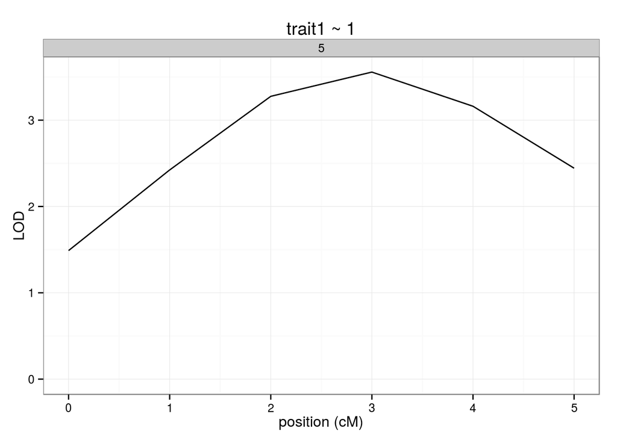

```r
plot(link)
```

# 7 Asssociation model

`summary` method applies the Bonferroni correction with a given value of `alpha` (the default value is 0.05).

```r
summary(assoc, alpha = 0.05)
```

```
##
## Call: solarAssoc(formula = trait1 ~ 1, data = dat30, snpcovdata = genocovdat30,
##     snpmap = mapdat30, cores = 2)
##
## Association model
##  * Number of SNPs: 100
##  * Input format: snpcovdata
##  * Number of significal SNPs: 1 (Bonferroni correction with alpha 0.05)
##       SNP NAv      chi     pSNP     bSNP   bSNPse   Varexp  est_maf
## 1: snp_86 174 15.30657 0.000091 0.917024 0.234391 0.049701 0.524075
##     est_mac dosage_sd      pos chr
## 1: 182.3781  0.582544 22883925   1
```

Table of the results is stored in `snpf` (**SNP** **f**rame) slot.

```r
head(assoc$snpf)
```

```
##        SNP NAv      chi     pSNP      bSNP   bSNPse   Varexp  est_maf
## 1:   snp_1 174 0.226982 0.633771 -0.128559 0.269840 0.004560 0.526714
## 2:  snp_10 174 0.634540 0.425695 -0.214068 0.268733 0.000000 0.482020
## 3: snp_100 174 0.917648 0.338093  0.245690 0.256478 0.000000 0.506701
## 4:  snp_11 174 2.094976 0.147784 -0.383326 0.264837 0.033637 0.497552
## 5:  snp_12 174 0.007396 0.931466 -0.020153 0.234334 0.001120 0.503480
## 6:  snp_13 174 1.455744 0.227608  0.283974 0.235362 0.013418 0.469853
##     est_mac dosage_sd      pos chr
## 1: 183.2965  0.547291  2105324   1
## 2: 167.7430  0.583412  2637674   1
## 3: 176.3319  0.588925 22914702   1
## 4: 173.1481  0.574507  2640705   1
## 5: 175.2110  0.596207  7447088   1
## 6: 163.5090  0.598493  7447236   1
```

The default plot method is Manhattan plot. The black dashed line shows the Bonferroni correction level at a given value of `alpha` (the default value is 0.05).

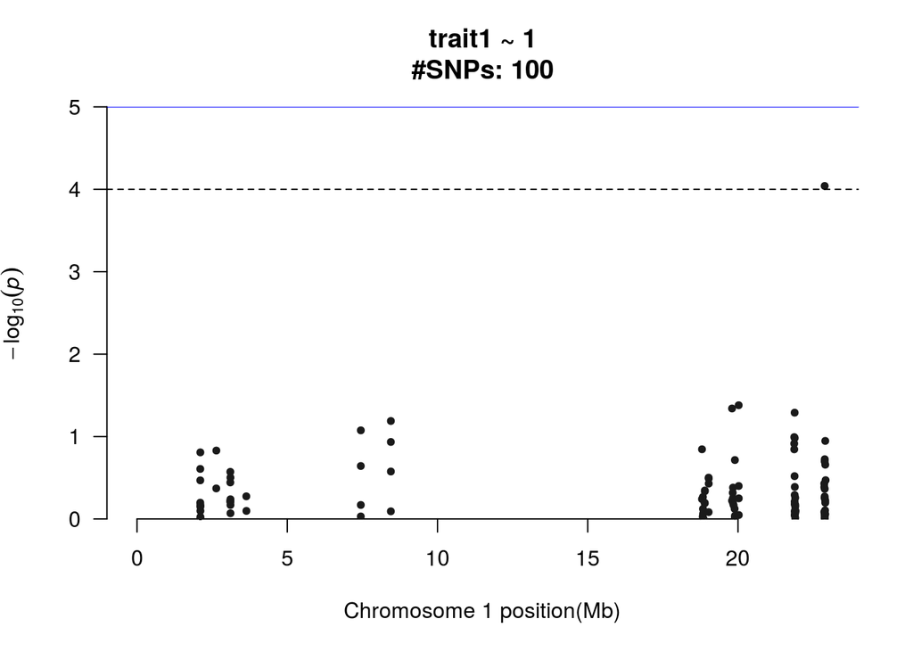

```r
plotManh(assoc, alpha = 0.01)
```

This call is equavalent to `plot(assoc, alpha = 0.01)`, as `plot` method applied to `assoc` object calls `plotManh` function.

The second plot available for `assoc` object is QQ-plot. The inflation parameter $\lambda$ (median method) is computed and dipicted at the bottom of the figure.

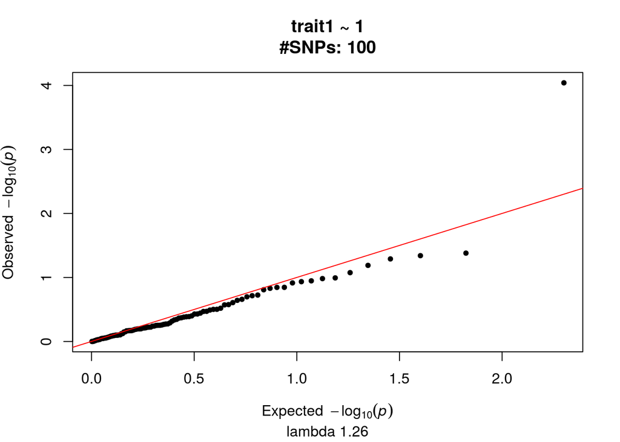

```r
plotQQ(assoc)
```

This call is equavalent to `plot(assoc, "qq")`, as `plot` method (applied to `assoc` object) with the second argument equal to `"qq"` calls `plotQQ` function.

The procedure of SNPs annotation is possible via `rsnps` R package (loaded by `annotate` function invisibly to the user).

```r
tab <- annotate(assoc)
tab
```

```
## Null data.table (0 rows and 0 cols)
```

Annotation of the synthetic SNPs generated for `dat30` data sets returns an empty data frame, since the names expected by `rsnps` R package must begin with *rs* symbols.

Meantime, annotation of the genome-wide significant SNPs from [GWAS of FXIc phenotype in GAIT1 data set](http://ugcd.github.io/solarius/vignettes/modelsGAIT1.html#fxi) (real data) is accomplished as following.

```r
snps <- c("rs710446", "rs4241824", "rs4253399")
tab <- annotate(snps)
tab
```

```
##        Query Chromosome    Marker Class Gene Alleles Major Minor    MAF
## 1:  rs710446          3  rs710446   snp KNG1     A/G     A     G 0.4153
## 2: rs4241824          4 rs4241824   snp  F11     A/G     A     G 0.4129
## 3: rs4253399          4 rs4253399   snp  F11     G/T     T     G 0.2638
##           BP
## 1: 186742137
## 2: 186270632
## 3: 186266939
```

In this case `annotate` function takes a vector of characters as its first argument.

# 9 License

This document is licensed under the Creative Commons Attribution 4.0 International Public License.